# Statistics and Financial Data Analysis

Problem Sheet 4

Gabor Bakos

08 November, 2016

The below function takes a data series x, and a maximum order k and fits all ARMA(p,q) models for p,q <= k. It prints out the AIC matrix where the (i,j) entry is the AIC of the ARMA(i,j) model, the order of the model and returns the best fitted model.

```r
ARMAfunct <- function(x,k){
  AIC.matrix<-matrix(nrow=k+1,ncol=k+1)
  for(i in 0:k){
    for(j in 0:k){
      current_model <- arima(x, order = c(i,0,j))
      AIC.matrix[i+1,j+1] <- current_model$aic
    }
  }
  print(AIC.matrix)
  minAIC = which(AIC.matrix==min(AIC.matrix), arr.ind = T)
  row <- minAIC[1,1]-1
  col <- minAIC[1,2]-1
  best_model <- arima(x, order = c(row,0,col))
  result<-data.frame(AIC.matrix,1,1)
  print("The AIC matrix with (i,j) entry with the AIC for the ARMA(i,j) model:")
  cat("\n")
  cat("\n")
  cat("\n")
  print(AIC.matrix)
  cat("\n")
  cat("\n")
  cat("\n")
  print("The order of the ARMA model with lowest AIC is:")
  order <- sum(minAIC[1,1]-1+minAIC[1,2]-1)
  print(order)
  cat("\n")
  cat("\n")
  cat("\n")
  print("The best ARMA model found: ")
  print(best_model)
  return(best_model)
}
#Test <- ARMAfunct(growth_97,6)
#fit97
```

```r
#setting working directory
setwd("~/Oxford_MCF/Statistics and Financial Data Analysis/Problem_Sheet_4")
#reading in cleaned data
Data<-read.csv("data_clean.csv", stringsAsFactors=F)
#head(Data)
#tail(Data)
```

The above data has both the yearly and quarterly values. So now find the subsection of the data that is quarterly and also remove values for 2015-16 as they will be predicted using the selected model.

```r
#This will convert the quarterly datapoitns into date format
date<-as.Date(as.yearqtr(Data$Date[57:278],format = "%Y Q%q"))
#removed last 6 entries to see predictions for 2015-16, below is a check to ensure the right subset was picked.
tail(date)
```

```
## [1] "2013-07-01" "2013-10-01" "2014-01-01" "2014-04-01" "2014-07-01"
## [6] "2014-10-01"
```

```r
OpW<-Data$OpW
OpWq <- OpW[57:278]
#the first entries of quarterly data
head(OpWq)
```

```
## [1] 34.7 35.3 36.1 35.7 36.2 36.3
```

```r
#the last entries of the quartely data (2014 Q4)
tail(OpWq)
```

```
## [1] 100.0  99.9 100.2 100.7 101.3 101.8
```

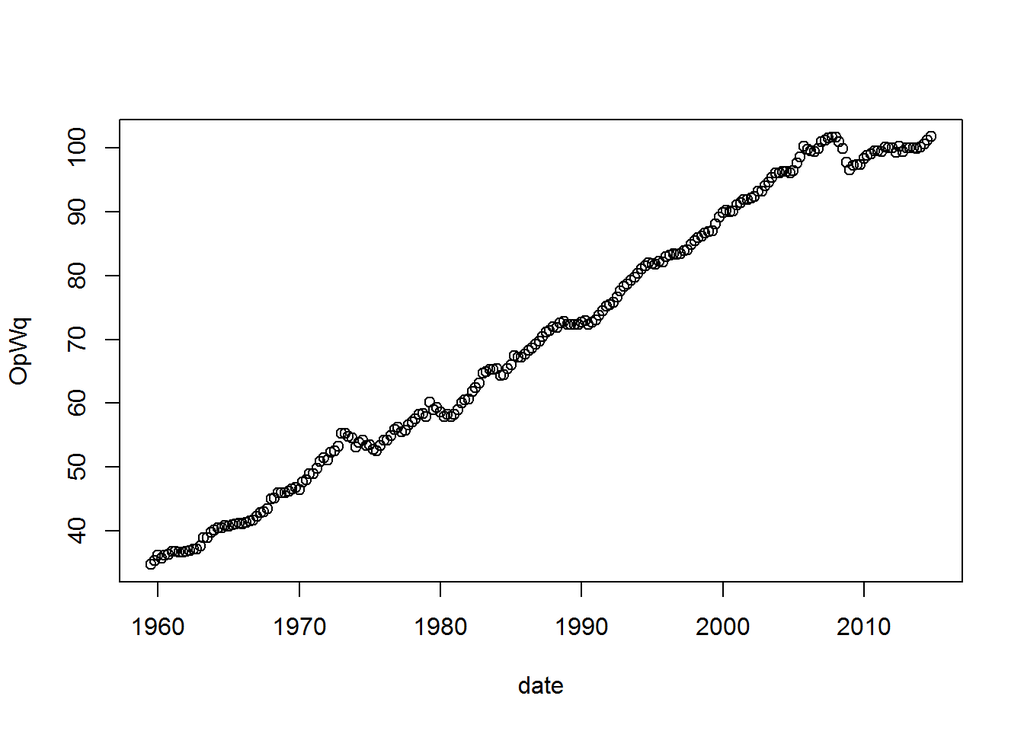

```r
#plotting the ooutput per worker over the years.
plot(date,OpWq)
```

Below are the plots of the growth of the output per worker, together with the acf(with no lag 0 term) and pacf plots.

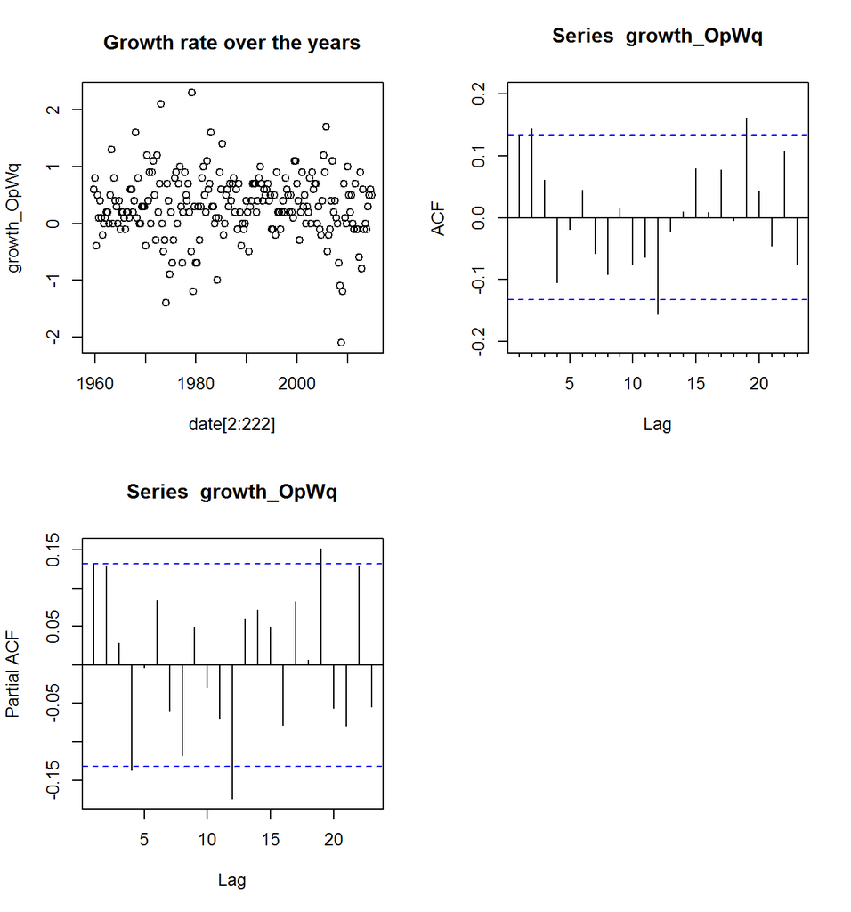

```r
growth_OpWq<-diff(OpWq,lag = 1)
par(mfrow=c(2,2))
plot(date[2:222],growth_OpWq, title("Growth rate over the years"))
Acf(growth_OpWq)
pacf(growth_OpWq)
```

# Finding the best ARMA model

This is done by using the auto.arima() function in R. Trace has been enabled to see which models are considered and to see if there is any one of the alternatives that could be also a good model for the growth in the output per worker.

```r
#help("auto.arima")
fit<-auto.arima(growth_OpWq,trace = TRUE)
```

```
##
##  ARIMA(2,0,2) with non-zero mean : 363.3367
##  ARIMA(0,0,0) with non-zero mean : 377.7078
##  ARIMA(1,0,0) with non-zero mean : 376.6421
##  ARIMA(0,0,1) with non-zero mean : 376.7167
##  ARIMA(0,0,0) with zero mean     : 431.9995
##  ARIMA(1,0,2) with non-zero mean : 375.531
##  ARIMA(3,0,2) with non-zero mean : 370.4872
##  ARIMA(2,0,1) with non-zero mean : 377.4101
##  ARIMA(2,0,3) with non-zero mean : 364.9053
##  ARIMA(1,0,1) with non-zero mean : 376.5047
##  ARIMA(3,0,3) with non-zero mean : 368.7071
##  ARIMA(2,0,2) with zero mean     : Inf
##
##  Best model: ARIMA(2,0,2) with non-zero mean
```

From the above output it is clear that the best ARMA model is ARMA(2,2). The best alternative is the ARMA(2,3), but it has slightly higher AIC and is a more complicated model, so (by Occam’s razor ) the ARMA(2,2) model will be used for the predictions.

The coefficients of AR and MA of the final model can be found in the below output together with the standard errors and the intercept.

```r
fit
```

```
## Series: growth_OpWq
## ARIMA(2,0,2) with non-zero mean
##
## Coefficients:
##          ar1      ar2     ma1     ma2  intercept
##       0.0282  -0.6979  0.0235  0.9329     0.3034
## s.e.  0.0783   0.0756  0.0433  0.0411     0.0420
##
## sigma^2 estimated as 0.2915:  log likelihood=-175.45
## AIC=362.9   AICc=363.29   BIC=383.29
```

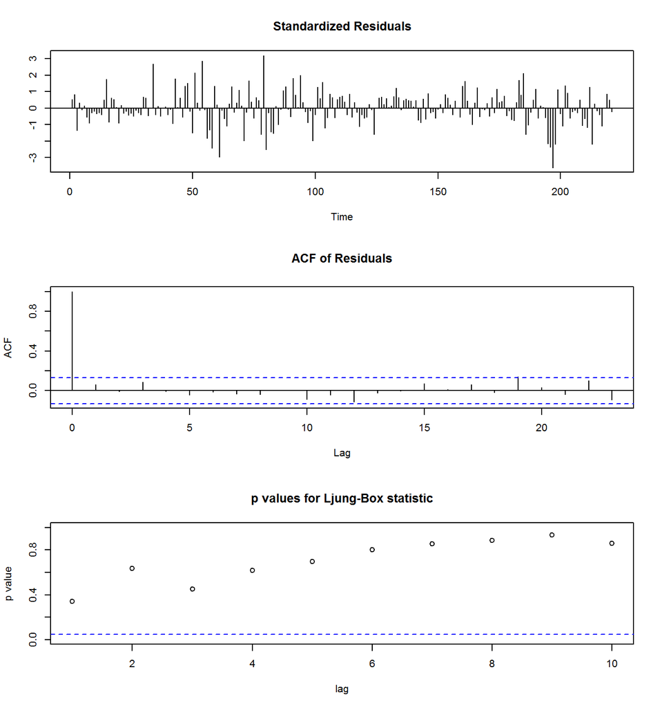

```r
tsdiag(fit)
```

```r
#help("Box.test")
Box.test(arima(growth_OpWq, c(2,0,2), method='ML')$residuals, type='L', lag=20,fitdf=4)
```

```
##
##  Box-Ljung test
##
## data:  arima(growth_OpWq, c(2, 0, 2), method = "ML")$residuals
## X-squared = 16.382, df = 16, p-value = 0.4267
```

From the above plots there is no evidence against the residuals not being white noise. (p>>0.05, therefor no reason to believe it is not White Noise.)

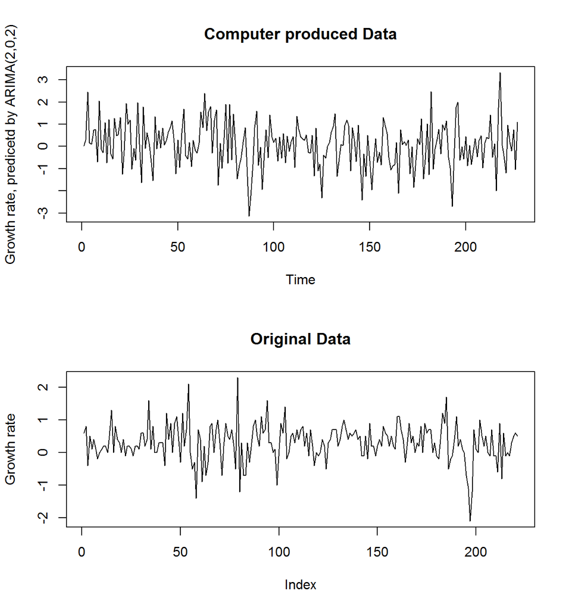

```r
par(mfrow=c(2,1))
plot(arima.sim(list(order = c(2,0,2), ar=fit$coef[1:2], ma =fit$coef[3:4],
                    sd = sqrt(fit$sigma2)), n=227), ylab
          = "Growth rate, predicetd by ARIMA(2,0,2)", main = "Computer produced Data")
plot(growth_OpWq,typ = 'l',ylab = "Growth rate", main = "Original Data")
```

The real and the predicted time series look very similar in nature. Therefore the model seems to work pretty well and now it can be used for forecasting.

# Predicting future behaviour of the growth rate

The below code could produce the plot for the prediction together with the confidence intervals, however since the forecast package is already loaded it will be also utilised for the prediction plots.

```r
#plot(growth_OpWq, type = 'l', xlim=c(1, length(growth_OpWq)+8))
#predictions<-predict(fit, n.ahead=8)
#predictions
#lines(length(growth_OpWq)+1:8, predictions$pred,col='blue')
#lines(length(growth_OpWq)+1:8, predictions$pred+1.96*predictions$se,col='red')
#lines(length(growth_OpWq)+1:8, predictions$pred-1.96*predictions$se,col='red')
```

```r
#help("forecast")
par(mfrow=c(1,1))
forecast(fit, h = 8)
```

```
##     Point Forecast      Lo 80     Hi 80      Lo 95    Hi 95
## 222     0.35365580 -0.3382143 1.0455259 -0.7044682 1.411780
## 223     0.06231705 -0.6304776 0.7551117 -0.9972209 1.121855
## 224     0.26155757 -0.4502967 0.9734118 -0.8271295 1.350245
## 225     0.47049630 -0.2416490 1.1826416 -0.6186359 1.559629
## 226     0.33733789 -0.3839953 1.0586711 -0.7658461 1.440522
## 227     0.18776807 -0.5336486 0.9091848 -0.9155435 1.291080
## 228     0.27648192 -0.4494013 1.0023652 -0.8336607 1.386625
## 229     0.38336594 -0.3425373 1.1092692 -0.7268073 1.493539
```

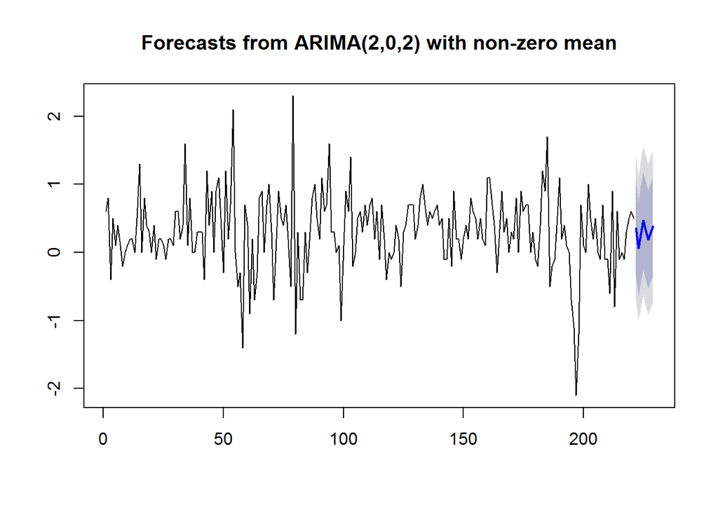

```r
plot(forecast(fit, h=8))
```

# Finding new models for periods 1997-2007 and 2008-2016

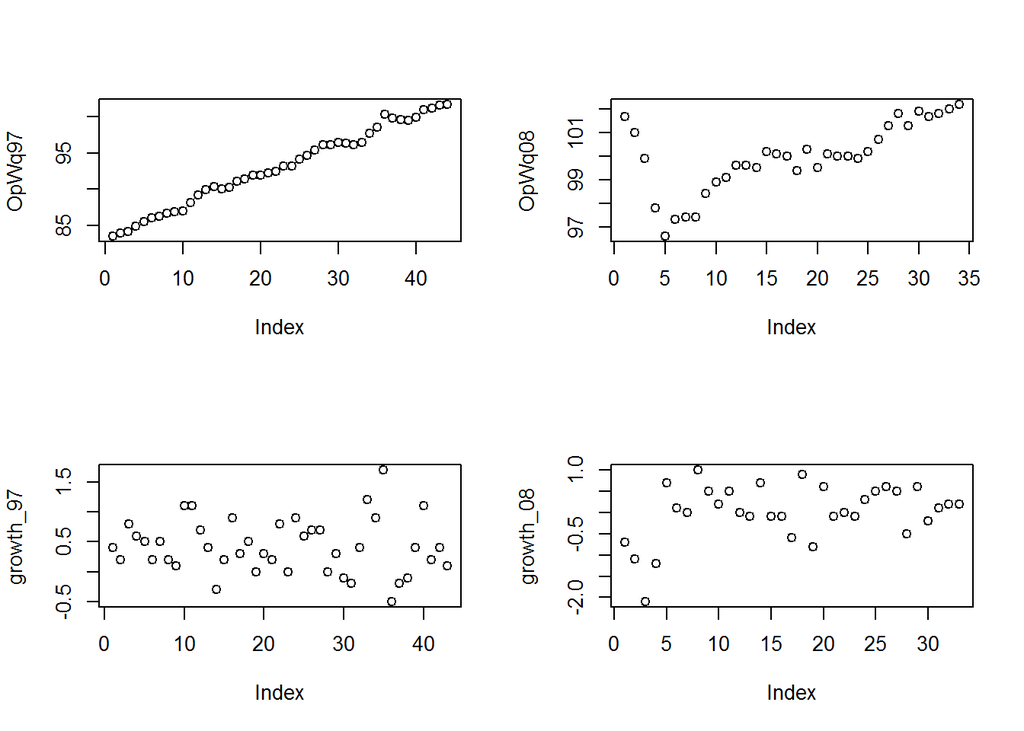

```r
#separating the dates
date97<-as.Date(as.yearqtr(Data$Date[207:250],format = "%Y Q%q"))
date08<-as.Date(as.yearqtr(Data$Date[251:284],format = "%Y Q%q"))
OpW<-Data$OpW
OpWq97 <- OpW[207:250]
future97 <- OpW[207:258]
OpWq08 <- OpW[251:284]
future08 <- OpW[251:284]
growth_97 <- diff(OpWq97,lag = 1)
gfuture97 <- diff(future97,lag = 1)
future08 <-
growth_08 <- diff(OpWq08,lag = 1)
par(mfrow=c(2,2))
plot(OpWq97)
plot(OpWq08)
plot(growth_97)
plot(growth_08)
```

Finding the best models fro the subsets of the data.

All test statistics suggest that the found models are doing a good job capturing the underlying data as the plots and the Ljung Box test both suggest that the residuals are white noise.

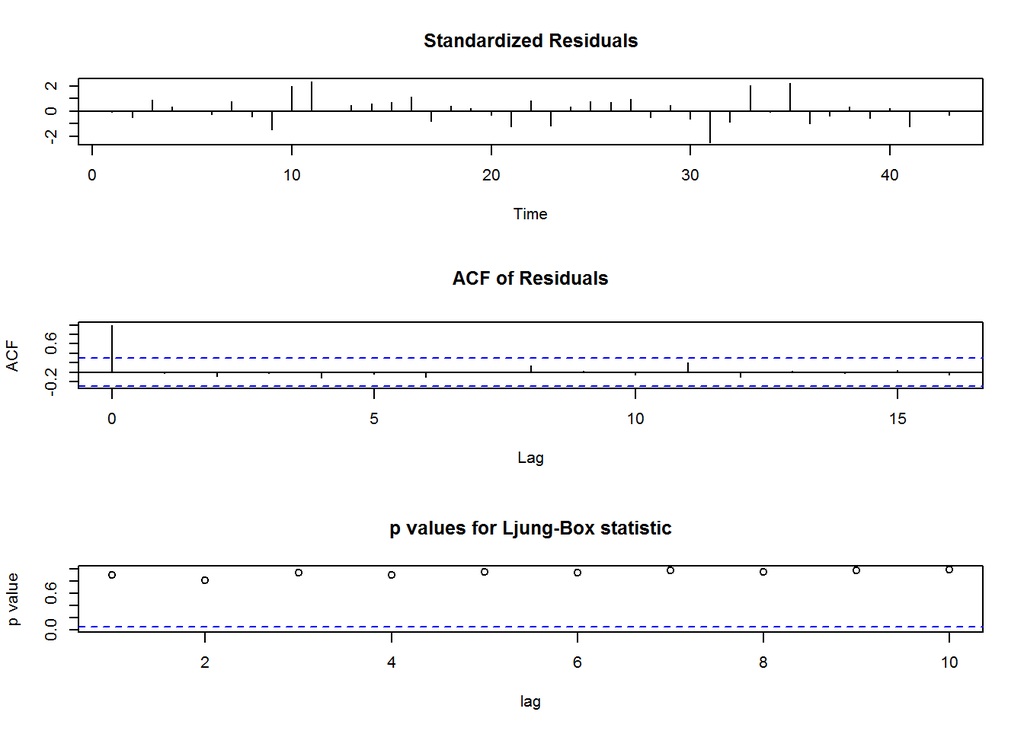

```r
tsdiag(fit97, tol=1)
```

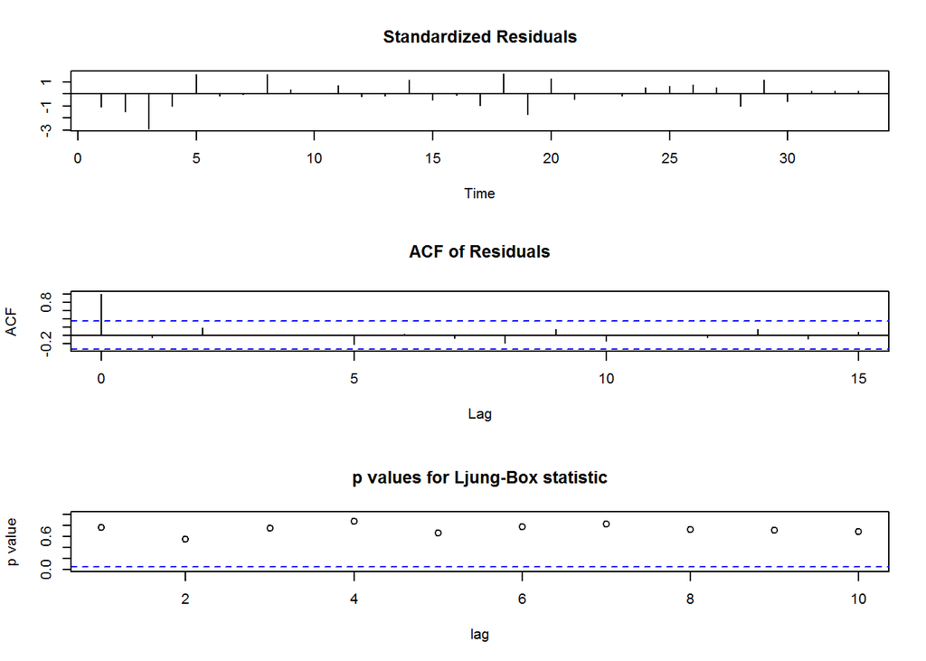

```r
tsdiag(fit08, tol=1)
```

```r
Box.test(arima(growth_97, c(2,0,3), method='ML')$residuals, type='L', lag=20,fitdf=4)
```

```
##
##  Box-Ljung test
##
## data:  arima(growth_97, c(2, 0, 3), method = "ML")$residuals
## X-squared = 8.9281, df = 16, p-value = 0.9163
```

```r
Box.test(arima(growth_08, c(1,0,0), method='ML')$residuals, type='L', lag=20,fitdf=4)
```

```
##
##  Box-Ljung test
##
## data:  arima(growth_08, c(1, 0, 0), method = "ML")$residuals
## X-squared = 10.826, df = 16, p-value = 0.8201
```

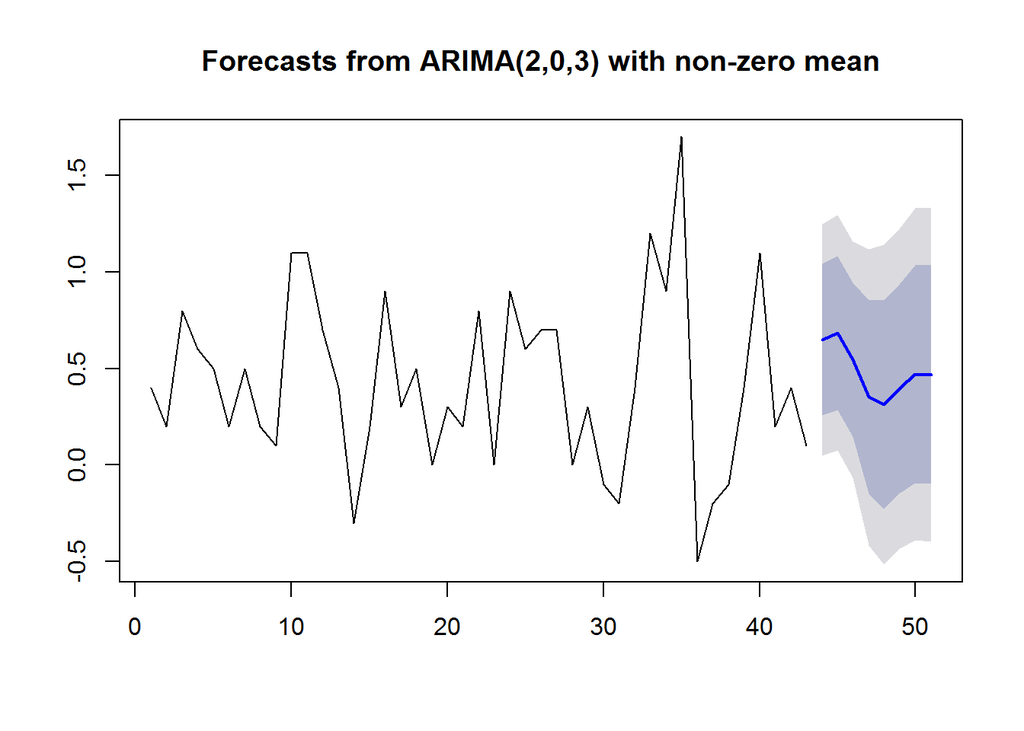

```r
fit97<-arima(growth_97, c(2,0,3),method='ML')
fit08<-arima(growth_08, c(1,0,0),method='ML')
plot(forecast(fit97, h=8))
```

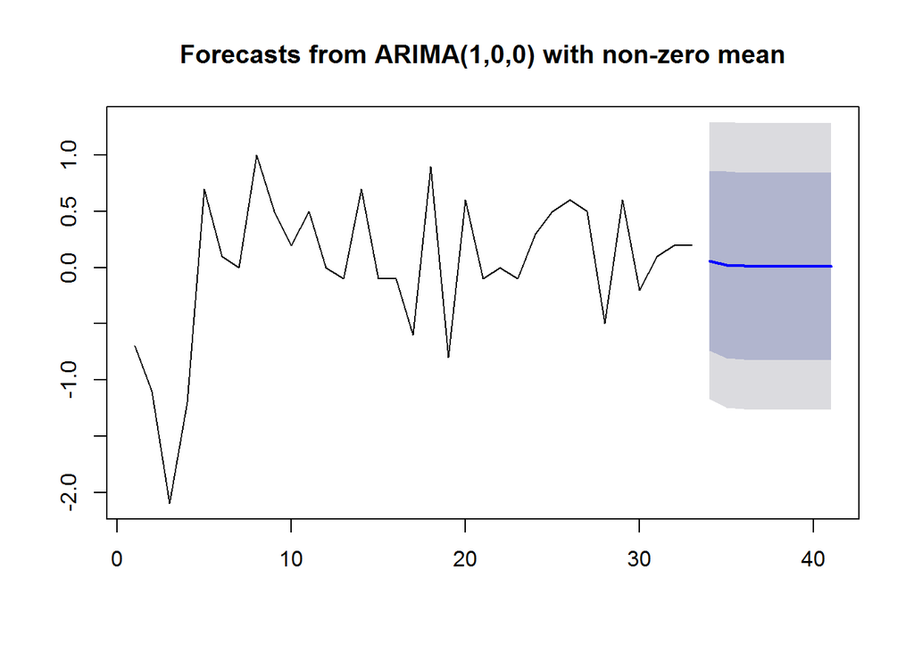

```r
plot(forecast(fit08, h=8))
```

The model for 97-07 is clearly not predicting the GFC, there is a huge decrease in productivity in 2008 which the model does not account for.

```r
x_1 <- fit97$coef[6]
s_1 <-fit97$var.coef[6,6]
x_2 <- fit08$coef[2]
s_2 <- fit08$var.coef[2,2]
t = (x_1 - x_2)/sqrt(s_1 + s_2)
v = (s_1 + s_2)^2/(s_1^4/4 + s_2^4/1)
dt(t,v)
```

```
##   intercept
## 0.007711479
```